# Problem statement - Term Deposit Subcription

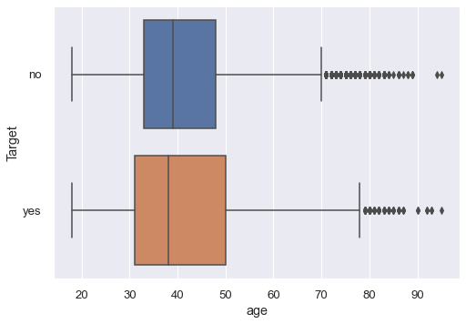

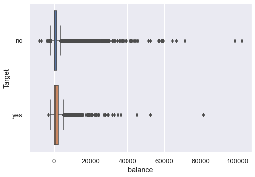

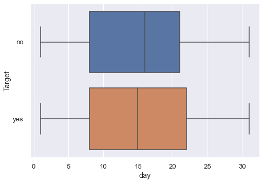

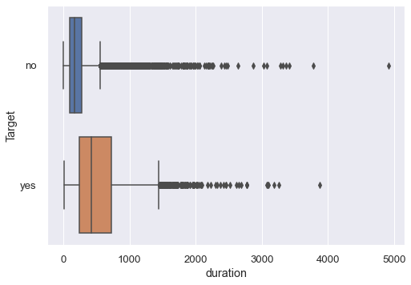

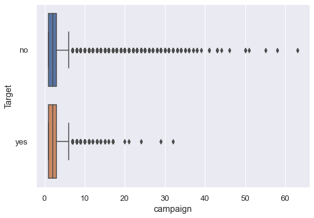

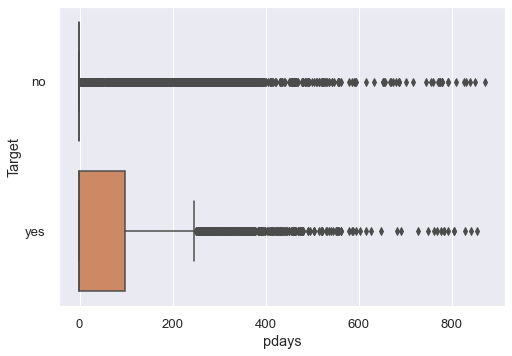

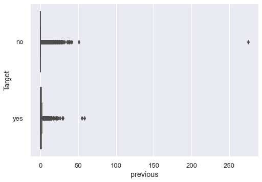

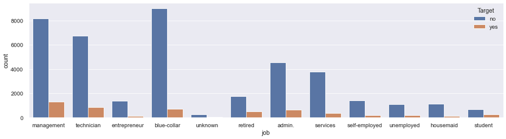

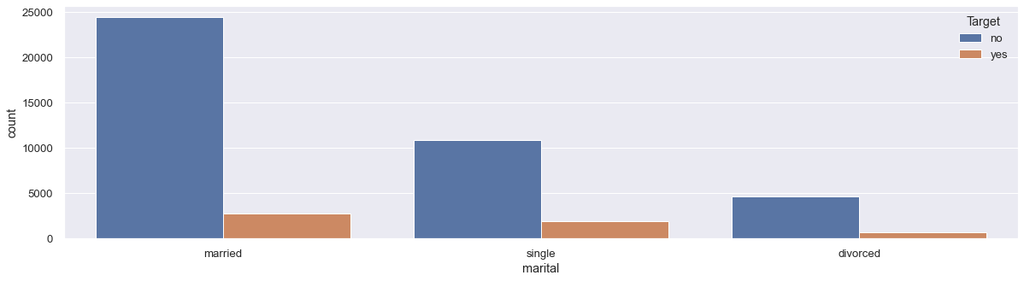

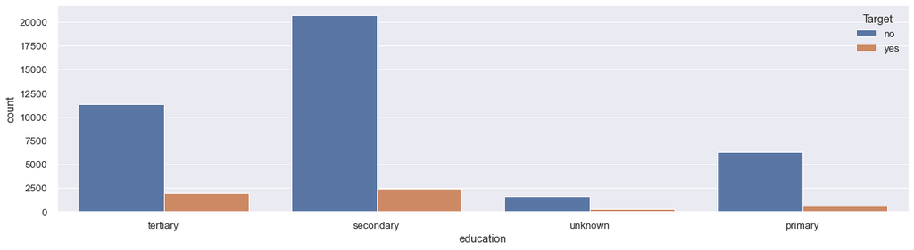

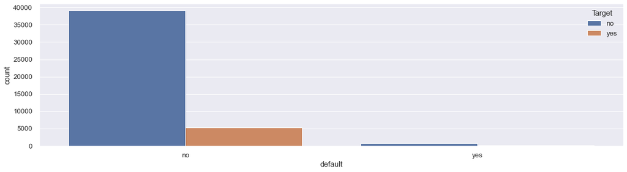

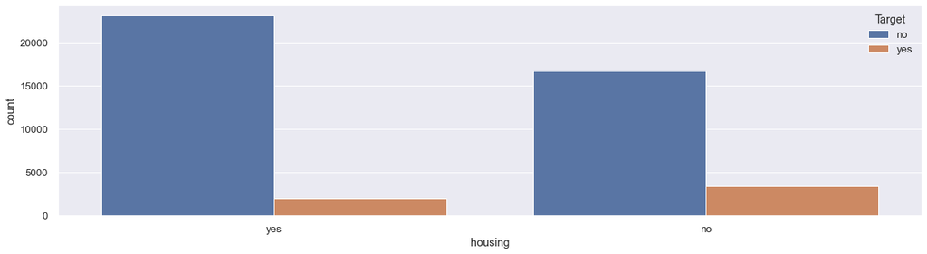

[4 more figures not shown]

```python
def plot_bivariate(dataframe,target):
    num_var=dataframe.select_dtypes(include='number')
    cat_var=dataframe.select_dtypes(include='object')
    sns.set(font_scale=1.2)
    for column in num_var.columns:
        sns.boxplot(x=dataframe[column],y=dataframe[target])
        plt.show()
    for column in cat_var.columns:
        if column!=target:
            plt.figure(figsize=(20,5))
            sns.countplot(dataframe[column],hue=dataframe[target])
            plt.show()

plot_bivariate(pdata,'Target')
```

```python
#Group numerical variables by mean for the classes of Y variable
np.round(pdata.groupby(["Target"]).mean() ,1)
```

| Target | age | balance | day | duration | campaign | pdays | previous |
| --- | --- | --- | --- | --- | --- | --- | --- |
| no | 40.8 | 1303.7 | 15.9 | 221.2 | 2.8 | 36.4 | 0.5 |
| yes | 41.7 | 1804.3 | 15.2 | 537.3 | 2.1 | 68.7 | 1.2 |

- The mean balance is higher for customers who subscribe to the term deposit compared to those who dont.
- Number of days that passed by after the client was last contacted from a previous campaign is higher for people who have subscribed.
- Length of duration is also higher for customers who subscribe.
- All of the above facts indicate that customers with a higher balance and those who have been in contact for longer duration tend to subscribe for the term deposit.

```python
pd.crosstab(pdata['job'], pdata['Target'], normalize='index').sort_values(by='yes',ascending=False )
```

| Target job | no | yes |
| --- | --- | --- |
| student | 0.713220 | 0.286780 |
| retired | 0.772085 | 0.227915 |
| unemployed | 0.844973 | 0.155027 |
| management | 0.862444 | 0.137556 |
| admin. | 0.877973 | 0.122027 |
| self-employed | 0.881571 | 0.118429 |
| unknown | 0.881944 | 0.118056 |
| technician | 0.889430 | 0.110570 |
| services | 0.911170 | 0.088830 |
| housemaid | 0.912097 | 0.087903 |
| entrepreneur | 0.917283 | 0.082717 |
| blue-collar | 0.927250 | 0.072750 |